# Analyse des mutations foncières dans l’EPCI du Pays Basque de 2014 à 2022

Antoine Soumet, Angéline Pinilo, Yanis Lepesant

30/11/2023

# Les données DVF à une échelle locale : les exemples de l’EPCI du Pays Basque et de la commune de Biarritz

Ce script décrit plusieurs fonctions de manipulation de la dimension spatiale des données DVF. Il propose aussi plusieurs formes de représentation cartographique de ces données à l’échelle d’un EPCI (Pays Basque).

## Chargement des packages nécessaires

```r
library(tidyverse)
library(sf)
library(cartography)
library(spdep)
library(geoR)
library(spatstat)
library(terra)
library(cluster)
library(linemap)
library(mapsf)
```

## Import du jeu de données brutes

```r
DVFOK <- read.csv("DVFOK.csv", encoding = "UTF-8")
```

## Transformer le jeu de données en objet spatial et définir son SCR

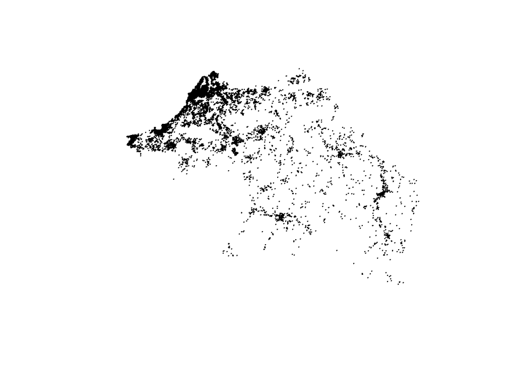

```r
DVFgeo <- st_as_sf(DVFOK, coords = c("longitude","latitude"), crs = 4326)
plot(st_geometry(DVFgeo), pch = 3, cex = 0.1)
```

```r
MutationsPaysBasque <- st_transform(DVFgeo, 2154)
```

## Cartes sur l’EPCI du Pays-Basque

### Recharger les couches et filtrer sur l’EPCI - si besoin (cf script 1)

```r
COM <- st_read('Communes.gpkg')
EPCI <- st_read('EPCI.gpkg')
COM_PB <- COM %>% filter(COM$SIREN_EPCI == "200067106")

#importer les données IRIS
IRIS <- st_read("IRIS.gpkg")
IRISPB <- IRIS %>% filter( INSEE_COM %in% COM_PB$INSEE_COM)
```

### Dénombrement du nombre de mutations de maisons et d’appartements par commune

```r
Maisons <- MutationsPaysBasque %>% filter(type == 'Maison')
summary(Maisons)
```

```
##       id                date               annee          type
##  Length:11685       Length:11685       Min.   :2014   Length:11685
##  Class :character   Class :character   1st Qu.:2016   Class :character
##  Mode  :character   Mode  :character   Median :2018   Mode  :character
##                                        Mean   :2018
##                                        3rd Qu.:2019
##                                        Max.   :2022
##       prix            surface          prixm2       codecommune
##  Min.   :  15000   Min.   : 14.0   Min.   :  595   Min.   :64008
##  1st Qu.: 245000   1st Qu.: 87.0   1st Qu.: 2329   1st Qu.:64100
##  Median : 362500   Median :110.0   Median : 3363   Median :64140
##  Mean   : 455471   Mean   :122.2   Mean   : 3753   Mean   :64232
##  3rd Qu.: 545775   3rd Qu.:145.0   3rd Qu.: 4643   3rd Qu.:64407
##  Max.   :3500000   Max.   :500.0   Max.   :19636   Max.   :64559
##    commune           Typo_INSEE                 geometry
##  Length:11685       Length:11685       POINT        :11685
##  Class :character   Class :character   epsg:2154    :    0
##  Mode  :character   Mode  :character   +proj=lcc ...:    0
##
##
##
```

```r
Appartements <- MutationsPaysBasque %>% filter(type == "Appartement")
COM_PB <- COM_PB %>% mutate(NbMaisons = lengths(st_intersects(COM_PB, Maisons))) %>% mutate(NbAppart = lengths(st_intersects(COM_PB, Appartements)))
summary(Appartements)
```

```
##       id                date               annee          type
##  Length:27243       Length:27243       Min.   :2014   Length:27243
##  Class :character   Class :character   1st Qu.:2016   Class :character
##  Mode  :character   Mode  :character   Median :2018   Mode  :character
##                                        Mean   :2018
##                                        3rd Qu.:2019
##                                        Max.   :2022
##       prix            surface           prixm2       codecommune
##  Min.   :  15000   Min.   :  9.00   Min.   :  593   Min.   :64008
##  1st Qu.: 136652   1st Qu.: 40.00   1st Qu.: 2674   1st Qu.:64102
##  Median : 185500   Median : 57.00   Median : 3542   Median :64122
##  Mean   : 228039   Mean   : 59.28   Mean   : 3970   Mean   :64180
##  3rd Qu.: 265000   3rd Qu.: 72.00   3rd Qu.: 4792   3rd Qu.:64260
##  Max.   :2857750   Max.   :300.00   Max.   :20000   Max.   :64559
##    commune           Typo_INSEE                 geometry
##  Length:27243       Length:27243       POINT        :27243
##  Class :character   Class :character   epsg:2154    :    0
##  Mode  :character   Mode  :character   +proj=lcc ...:    0
##
##
##
```

### Création d’un tableau avec les indicateurs immobiliers du Pays-Basque

```r
RecaPaysBasque <- MutationsPaysBasque %>% group_by(type) %>%
  summarise(tot = n(), prixmed = round(median(prix)), prixmoy = round(mean(prix)), surfmed = round(median(surface)), surfmoy = round(mean(surface)), prixm2med = round(median(prixm2)), prixm2moy = round(mean(prixm2)))

RecaPaysBasque <- RecaPaysBasque %>% mutate(part = (tot/sum(tot)*100))
print(RecaPaysBasque)
```

```
## Simple feature collection with 2 features and 9 fields
## Geometry type: MULTIPOINT
## Dimension:     XY
## Bounding box:  xmin: 312132.6 ymin: 6217807 xmax: 394680.4 ymax: 6281369
## Projected CRS: RGF93 v1 / Lambert-93
## # A tibble: 2 × 10
##   type          tot prixmed prixmoy surfmed surfmoy prixm2med prixm2moy
## * <chr>       <int>   <dbl>   <dbl>   <dbl>   <dbl>     <dbl>     <dbl>
## 1 Appartement 27243  185500  228039      57      59      3542      3970
## 2 Maison      11685  362500  455471     110     122      3363      3753
## # ℹ 2 more variables: geometry <MULTIPOINT [m]>, part <dbl>
```

### Calculer et cartographier le prix moyen au m² par commune

```r
# Calcul du prix moyen au m² par commune
COM_DVF <- COM_PB %>% st_join(MutationsPaysBasque) %>% group_by(INSEE_COM) %>% summarise(Prixm2 = round(mean(prixm2)))

#histogramme et résumé du Prix au m2 pour choisir les seuils de classes
summary(COM_DVF$Prixm2)
```

```
##    Min. 1st Qu.  Median    Mean 3rd Qu.    Max.    NA's
##     682    1351    1640    1984    2389    5779       2
```

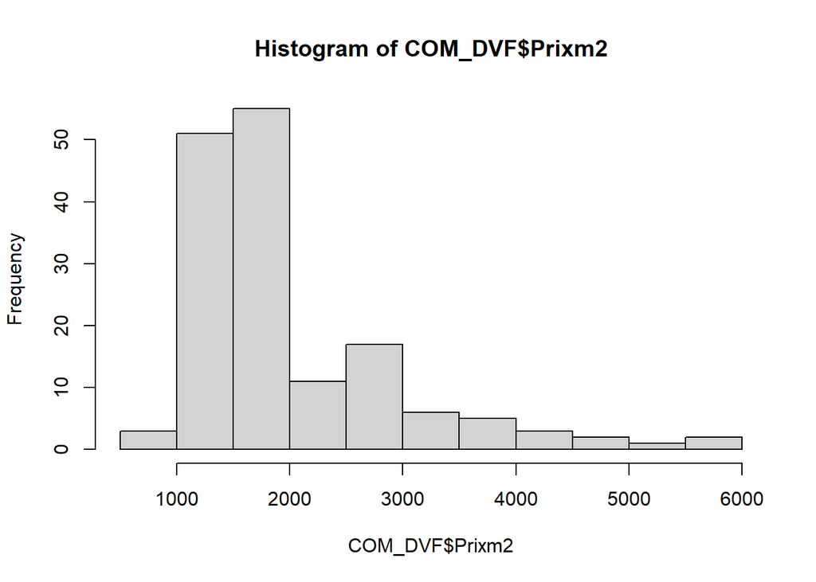

```r
hist(COM_DVF$Prixm2)
```

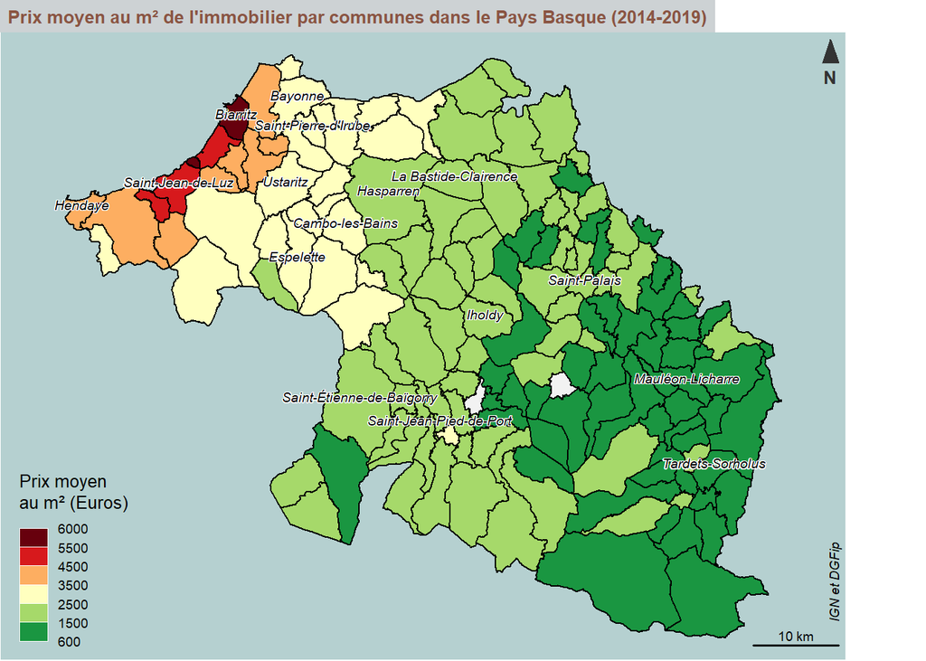

```r
#retrait des NA pour les communes de Bunus et Bustince-Iriberry (pas de vente entre 2014 et 2019)
COM_DVF <- na.omit(COM_DVF)

# Sélection des communes dont le nom sera affiché sur la carte
liste_noms_communes <- c("La Bastide-Clairence","Bayonne","Biarritz","Cambo-les-Bains","Espelette","Hasparren","Hendaye","Iholdy","Mauléon-Licharre", "Saint-Jean-de-Luz","Saint-Pierre-d'Irube", "Saint-Étienne-de-Baïgorry" ,"Saint-Jean-Pied-de-Port", "Saint-Palais","Tardets-Sorholus", "Ustaritz")

Selection_communes_PaysBasque <- COM_PB[which(COM_PB$NOM %in% liste_noms_communes),]

# Paramétrage des marges de la fenêtre pour maximiser l'emprise de la carte
par(mar = c(0, 0, 1.2, 3))

# Affichage des communes du Pays Basque et alentours en arrière-plan et centrage de la carte sur Pays Basque
plot(st_geometry(EPCI), lwd = 0.1, col = "grey95", border = "white", bg = "#B5D0D0", xlim = c(st_bbox(COM_PB)[1], st_bbox(COM_PB)[3]), ylim = c(st_bbox(COM_PB)[2], st_bbox(COM_PB)[4]))

choroLayer(
  x = COM_DVF,
  var = "Prixm2",
  breaks = c(600, 1500, 2500, 3500, 4500, 5500, 6000),
  col = c("#1a9641", "#a6d96a", "#ffffbf", "#fdae61", "#d7191c", "#67000d"),
  add = TRUE,
  border = "black",
  legend.nodata = "Aucune mutation",
  legend.border = "white",
  legend.title.txt = "Prix moyen \nau m² (Euros)")

layoutLayer(title = "Prix moyen au m² de l'immobilier par communes dans le Pays Basque (2014-2019)", source = "         IGN et DGFip",
            north = TRUE, horiz = FALSE, tabtitle = TRUE,
            frame = FALSE, col = "#cdd2d4", coltitle = "#8A5543")

# Ajouter les étiquettes des communes selectionnées plus haut
labelLayer(Selection_communes_PaysBasque, txt = "NOM", halo = TRUE, bg = "white", r = 0.05, cex = 0.6, pos = 3, font = 3, offset = 0, overlap = TRUE)
```

### Calculer et cartographier le nombre de mutations par commune

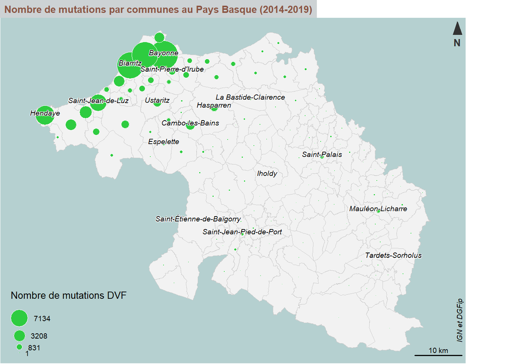

```r
# Calcul du nombre de mutations par commune
COM_DVF <- COM_DVF %>% mutate(Nbmutations = lengths(st_intersects(COM_DVF, MutationsPaysBasque)))
COM_DVF <- COM_DVF %>% na.omit() # pour supprimer les valeurs manquantes

# Paramétrage des marges de la fenêtre pour maximiser l'emprise de la carte
par(mar = c(0, 0, 1.2, 3))

# Affichage des communes du Pays Basque et alentours en arrière-plan et centrage de la carte sur le Pays Basque
plot(st_geometry(EPCI), lwd = 0.1, col = "grey95", border = "white", bg = "#B5D0D0", xlim = c(st_bbox(COM_PB)[1], st_bbox(COM_PB)[3]), ylim = c(st_bbox(COM_PB)[2], st_bbox(COM_PB)[4]))

# Affichage des communes
plot(st_geometry(COM_PB), # appel du jeu de données
     border = "grey80", # couleur de la bordure des communes
     add = TRUE,
     lwd = 0.05)

# Affichage des symboles proportionnels (nombre de mutations)
propSymbolsLayer(x = COM_DVF, # appel du jeu de données
                 var = "Nbmutations", # appel de la variable à cartographier
                 col = "#2ECC40", # couleur des cercles
                 border = "white",  # couleur du contour des cercles
                 lwd = 0.01,
                 inches = 0.20, # Taille des cercles
                 add = TRUE,
                 legend.pos = "n",
                 )

layoutLayer(title = "Nombre de mutations par communes au Pays Basque (2014-2019)", source = "         IGN et DGFip", north = TRUE, horiz = FALSE, tabtitle = TRUE, frame = FALSE, col = "#cdd2d4", coltitle = "#8A5543")

legendCirclesSymbols(
  pos = "bottomleft",
  title.txt = "Nombre de mutations DVF",
  title.cex = 0.8,
  cex = 1,
  border = "white",
  lwd = 0.01,
  values.cex = 0.6,
  var = c(min(COM_DVF$Nbmutations), max(COM_DVF$Nbmutations)),
  inches = 0.12,
  col = "#2ECC40",
  frame = FALSE,
  values.rnd = 0,
  style = "e"
)

# Ajouter les étiquettes des communes selectionnées plus haut
labelLayer(Selection_communes_PaysBasque, txt = "NOM", halo = TRUE, bg = "white", r = 0.05, cex = 0.6, pos = 3, font = 3, offset = 0, overlap = TRUE)
```

## Exploration des prix et des volumes à l’échelon des sections cadastrales

### Importer la couche des sections cadastrales (DGFip)

```r
Sections <- st_read("section_CCBASQUE.gpkg")
```

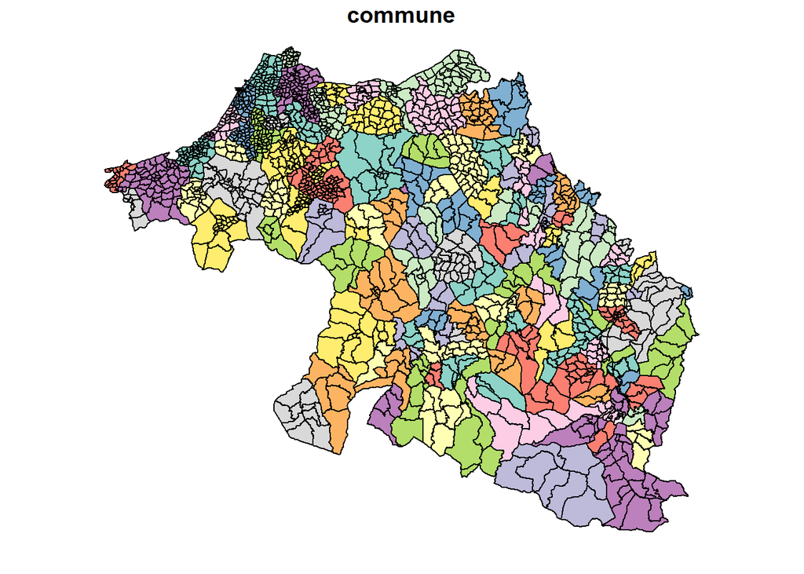

```r
Sections <- Sections %>% mutate(codesection = id)
plot(Sections["commune"])
```

### Calculer et cartographier le prix moyen au m² par section cadastrale

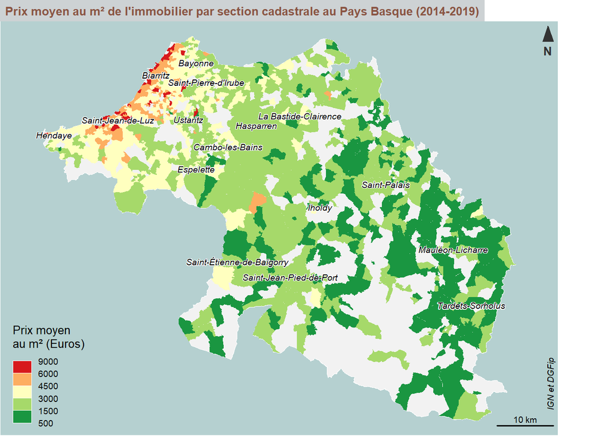

```r
# Calcul du prix moyen au m² par section
SectionsDVF <- Sections %>% st_join(MutationsPaysBasque) %>% group_by(codesection) %>% summarise(Prixm2 = round(mean(prixm2)))
SectionsDVF <- SectionsDVF %>% na.omit() # pour supprimer les valeurs manquantes

# Paramétrage des marges de la fenêtre pour maximiser l'emprise de la carte
par(mar = c(0, 0, 1.2, 3))

# Affichage des communes du Pays Basque et alentours en arrière-plan et centrage de la carte sur l'EPCI du Pays Basque
plot(st_geometry(EPCI), lwd = 0.1, col = "grey95", border = "white", bg = "#B5D0D0", xlim = c(st_bbox(COM_PB)[1], st_bbox(COM_PB)[3]), ylim = c(st_bbox(COM_PB)[2], st_bbox(COM_PB)[4]))

# Affichage de la carte des prix au m² par section cadastrale
choroLayer(
  x = SectionsDVF,
  var = "Prixm2",
  breaks = c(500, 1500, 3000, 4500, 6000, 9000),
  col = c("#1a9641", "#a6d96a", "#ffffbf", "#fdae61", "#d7191c"),
  add = TRUE,
  border = NA,
  legend.nodata = "Aucune mutation",
  legend.border = "white",
  legend.title.txt = "Prix moyen \nau m² (Euros)")

layoutLayer(title = "Prix moyen au m² de l'immobilier par section cadastrale au Pays Basque (2014-2019)", source = "         IGN et DGFip",
            north = TRUE, horiz = FALSE, tabtitle = TRUE,
            frame = FALSE, col = "#cdd2d4", coltitle = "#8A5543")

# Ajouter les étiquettes des communes selectionnées plus haut
labelLayer(Selection_communes_PaysBasque, txt = "NOM", halo = TRUE, bg = "white", r = 0.05, cex = 0.6, pos = 3, font = 3, offset = 0, overlap = TRUE)
```

### Calculer et cartographier le nombre de mutations par section cadastrale

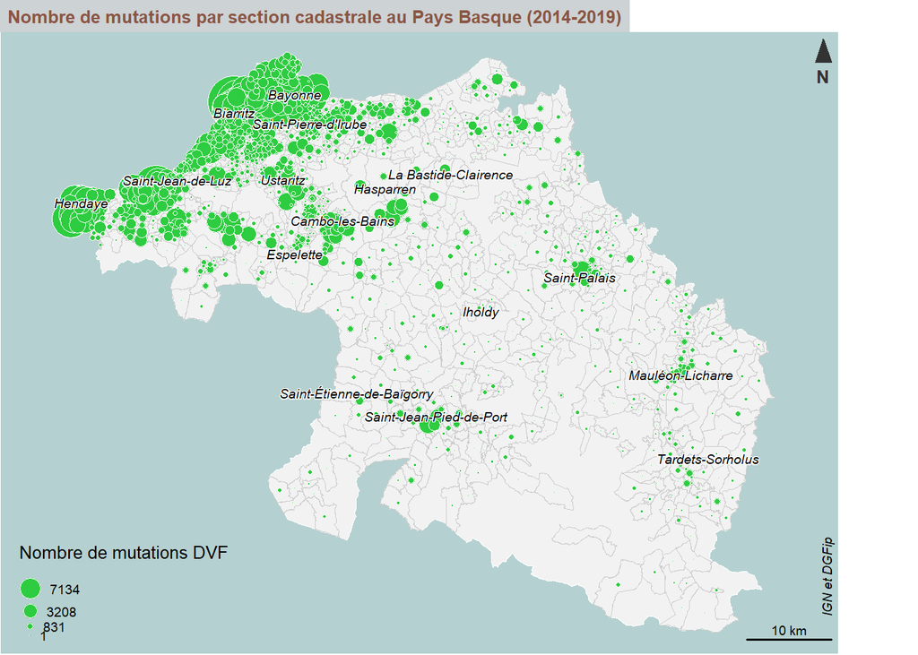

```r
# Calcul du nombre de mutations par section
SectionsDVF <- SectionsDVF %>% mutate(Nbmutations = lengths(st_intersects(SectionsDVF, MutationsPaysBasque)))

# Paramétrage des marges de la fenêtre pour maximiser l'emprise de la carte
par(mar = c(0, 0, 1.2, 3))

# Affichage des communes du Pays Basque et alentours en arrière-plan et centrage de la carte sur l' EPCI du Pays Basque
plot(st_geometry(EPCI), lwd = 0.1, col = "grey95", border = "white", bg = "#B5D0D0", xlim = c(st_bbox(COM_PB)[1], st_bbox(COM_PB)[3]), ylim = c(st_bbox(COM_PB)[2], st_bbox(COM_PB)[4]))

# Affichage des sections cadastrales
plot(st_geometry(SectionsDVF), # appel du jeu de données
     border = "grey80", # couleur de la bordure
     add = TRUE,
     lwd = 0.05)

# Affichage des symboles proportionnels (nombre de mutations)
propSymbolsLayer(x = SectionsDVF, # appel du jeu de données
                 var = "Nbmutations", # appel de la variable à cartographier
                 col = "#2ECC40", # couleur cercles
                 border = "white",  # couleur du contour des cercles
                 lwd = 0.01,
                 inches = 0.20, # Taille des cercles
                 add = TRUE,
                 legend.pos = "n",
                 )

layoutLayer(title = "Nombre de mutations par section cadastrale au Pays Basque (2014-2019)", source = "         IGN et DGFip", north = TRUE, horiz = FALSE, tabtitle = TRUE, frame = FALSE, col = "#cdd2d4", coltitle = "#8A5543")

legendCirclesSymbols(
  pos = "bottomleft",
  title.txt = "Nombre de mutations DVF",
  title.cex = 0.8,
  cex = 1,
  border = "white",
  lwd = 0.01,
  values.cex = 0.6,
  var = c(min(COM_DVF$Nbmutations), max(COM_DVF$Nbmutations)),
  inches = 0.08,
  col = "#2ECC40",
  frame = FALSE,
  values.rnd = 0,
  style = "e"
)

# Ajouter les étiquettes des communes selectionnées plus haut
labelLayer(Selection_communes_PaysBasque, txt = "NOM", halo = TRUE, bg = "white", r = 0.05, cex = 0.6, pos = 3, font = 3, offset = 0, overlap = TRUE)
```

## Lissage spatial (échelle de l’EPCI)

## Lissage spatial des prix de l’immobilier au m² calculés à partir des valeurs agrégées par commune

### Calcul des distances au plus proche voisin et de l’auto-corrélation spatiale des prix au m²

```r
# pour calculer les pseudo-centroides des communes (indispensable pour le calcul sur les plus proches voisins)
COM_DVF.Centroids <- st_point_on_surface(COM_DVF)

# Identification du plus proche voisin de chaque communes
listPPV <- knearneigh(COM_DVF.Centroids, k = 1) # pour connaître le plus proche voisin de chaque communes
PPV <- knn2nb(listPPV, row.names = COM_DVF.Centroids$INSEE_COM) # pour convertir l'objet knn en objet nb
distPPV <- nbdists(PPV, COM_DVF.Centroids) # pour connaître la distance entre plus proches voisins
print(as.data.frame(t(as.matrix(summary(unlist(distPPV))))))
```

```
##       Min.  1st Qu.   Median     Mean  3rd Qu.     Max.
## 1 1283.566 2357.879 2909.791 3102.962 3581.224 8434.484
```

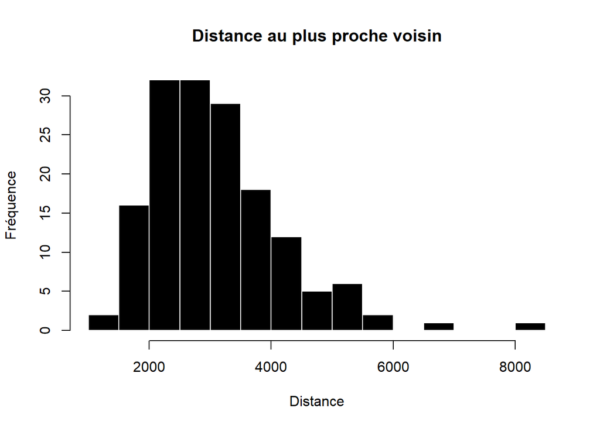

```r
hist(unlist(distPPV), breaks = 20,
     main = "Distance au plus proche voisin",
     col = "black", border = "white", xlab = "Distance", ylab = "Fréquence")
```

```r
# pour convertir les Iris en objet nb
COM.nb <- poly2nb(pl = COM_DVF,
                 snap = 50,
                 queen = TRUE)

#calcul du test de Moran
moran.test(COM_DVF.Centroids$Prixm2, listw = nb2listw(COM.nb))
```

```
##
##  Moran I test under randomisation
##
## data:  COM_DVF.Centroids$Prixm2
## weights: nb2listw(COM.nb)
##
## Moran I statistic standard deviate = 17.535, p-value < 2.2e-16
## alternative hypothesis: greater
## sample estimates:
## Moran I statistic       Expectation          Variance
##       0.876470451      -0.006451613       0.002535463
```

### Carte lissée des prix de l’immobilier au m² calculés à partir des valeurs agrégées par commune sur l’ensemble de l’EPCI du Pays Basque

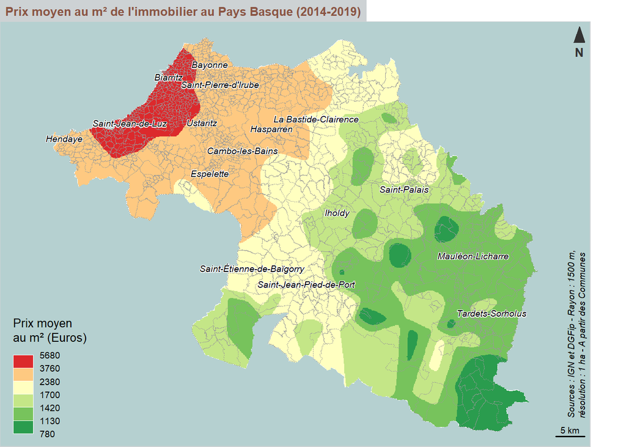

```r
# pour définir le contour du Pays Basque comme emprise pour le lissage (sinon le lissage est calculé sur une fenêtre rectangulaire)
EmpriseBP <- as.owin(st_geometry(EPCI))

# pour récupérer les coordonnées du centroïde des communes
pts <- st_coordinates(st_point_on_surface(st_geometry(COM_DVF)))

# pour créer un objet ppp (format spatstat) et y intégrer dedans l'emprise et les valeurs à lisser (prix au m²)
COM_DVF.ppp <- ppp(pts[,1], pts[,2], window = EmpriseBP, marks = COM_DVF$Prixm2)

# pour calculer la surface lissée (rayon lissage : 1 km et resolution spatiale de l'image : 1 ha)
cartelissee <- Smooth(COM_DVF.ppp, sigma = 1500, weights = COM_DVF.ppp$marks, eps = 100)

# Conversion de la surface lissée au format raster
cartelissee.raster <- terra::rast(cartelissee)
crs(cartelissee.raster) <- st_crs(COM_PB)$srid

# Paramétrage des marges de la fenêtre pour maximiser l'emprise de la carte
par(mar = c(0, 0, 1.2, 2))

# pour afficher la surface lissée et définir l'habillage
# Calcul des seuils
bks <- unique(getBreaks(values(cartelissee.raster), method = "q6"))

# Création d'une palette de couleurs (double gradation harmonique)
cols <- c("#2a9c4e", "#77c35c", "#c4e687", "#ffffc0", "#fec981", "#dc292c")

# Affichage des communes du Pays Basque et alentours en arrière-plan et centrage de la carte sur l'EPCI
plot(st_geometry(EPCI), lwd = 0.1, col = "grey95", border = "white", bg = "#B5D0D0", xlim = c(st_bbox(COM_PB)[1], st_bbox(COM_PB)[3]), ylim = c(st_bbox(COM_PB)[2], st_bbox(COM_PB)[4]))

# Affichage de la carte lissée et du contour des communes
plot(cartelissee.raster, breaks = bks, col = cols, add = T, legend = F)
plot(SectionsDVF$geom, border = "grey60", lwd = 0.05, lty = 3, add = T)

legendChoro(
  pos = "bottomleft",
  title.txt = "Prix moyen \nau m² (Euros)",
  breaks = bks,
  nodata = FALSE,
  values.rnd = -1,
  border = "white",
  col = cols
)

# Habillage de la carte
layoutLayer(title = "Prix moyen au m² de l'immobilier au Pays Basque (2014-2019)",
            author = "          Sources : IGN et DGFip - Rayon : 1500 m,\n          résolution : 1 ha - A partir des Communes",
            scale = 5, frame = TRUE, col = "#cdd2d4", coltitle = "#8A5543",
            north = TRUE, tabtitle = TRUE, horiz = FALSE)

# Ajouter les étiquettes des communes sélectionnées plus haut
labelLayer(Selection_communes_PaysBasque, txt = "NOM", halo = TRUE, bg = "white", r = 0.05, cex = 0.6, pos = 3, font = 3, offset = 0)
```

## Lissage spatial du prix de l’immobilier au m² calculés à partir des valeurs agrégées par section cadastrale

### Calcul des distances au plus proche voisin et de l’auto-corrélation spatiale des prix au m²

```r
# pour calculer les pseudo-centroides des sections cadastrales (indispensable pour le calcul sur les plus proches voisins)
SectionsDVF.Centroids <- st_point_on_surface(SectionsDVF)

# Calcul sur les plus proches voisins
listPPV <- knearneigh(SectionsDVF.Centroids, k = 1) # pour connaître le plus proche voisin de chaque section cadastrale

#distances <- result$nn.dist
#rayon <- 0.5  # Exemple de rayon
#voisins_dans_rayon <- lapply(distances, function(x) which(x <= rayon))

PPV <- knn2nb(listPPV, row.names = SectionsDVF.Centroids$codesection) # pour convertir l'objet knn en objet nb
distPPV <- nbdists(PPV, SectionsDVF.Centroids) # pour connaître la distance entre plus proches voisins
print(as.data.frame(t(as.matrix(summary(unlist(distPPV))))))
```

```
##       Min.  1st Qu.   Median     Mean  3rd Qu.     Max.
## 1 200.0904 450.4694 687.8912 868.0602 1090.454 6050.291
```

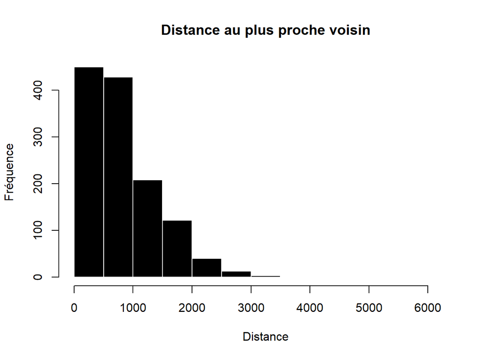

```r
hist(unlist(distPPV), breaks = 20,
     main = "Distance au plus proche voisin",
     col = "black", border = "white", xlab = "Distance", ylab = "Fréquence")
```

```r
# pour convertir les sections en objet nb
Section.nb <- poly2nb(pl = SectionsDVF,
                 snap = 1500,
                 queen = TRUE)

#calcul du test de Moran
moran.test(SectionsDVF$Prixm2, listw = nb2listw(Section.nb))
```

```
##
##  Moran I test under randomisation
##
## data:  SectionsDVF$Prixm2
## weights: nb2listw(Section.nb)
##
## Moran I statistic standard deviate = 69.68, p-value < 2.2e-16
## alternative hypothesis: greater
## sample estimates:
## Moran I statistic       Expectation          Variance
##      6.955598e-01     -7.898894e-04      9.987219e-05
```

### Carte lissée des prix de l’immobilier au m² calculés à partir des valeurs agrégées par section cadastrale sur l’ensemble du Pays Basque

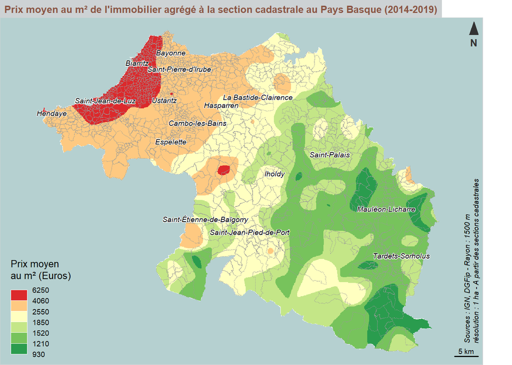

```r
# pour définir le contour du Pays Basque comme emprise pour le lissage (sinon le lissage est calculé sur une fenêtre rectangulaire)
EmpriseBP <- as.owin(st_geometry(EPCI))

# pour récupérer les coordonnées du centroïde des sections
pts <- st_coordinates(st_point_on_surface(st_geometry(SectionsDVF)))

# pour créer un objet ppp (format spatstat) et y intégrer dedans l'emprise et les valeurs à lisser (prix au m²)
Sections.ppp <- ppp(pts[,1], pts[,2], window = EmpriseBP, marks = SectionsDVF$Prixm2)
# pour calculer la surface lissée (rayon lissage : 1 km et resolution spatiale de l'image : 1 ha)
cartelissee <- Smooth(Sections.ppp, sigma = 1500, weights = Sections.ppp$marks, eps = 100)

# Conversion de la surface lissée au format raster
cartelissee.raster <- terra::rast(cartelissee)
crs(cartelissee.raster) <- st_crs(COM_PB)$srid

# Paramétrage des marges de la fenêtre pour maximiser l'emprise de la carte
par(mar = c(0, 0, 1.2, 2))

# pour afficher la surface lissée et définir l'habillage
# Calcul des seuils
bks <- unique(getBreaks(values(cartelissee.raster), method = "q6"))

# Création d'une palette de couleurs (double gradation harmonique)
cols <- c("#2a9c4e", "#77c35c", "#c4e687", "#ffffc0", "#fec981", "#dc292c")

# Affichage des communes du Pays Basque et alentours en arrière-plan et centrage de la carte sur le Pays Basque
plot(st_geometry(COM_PB), lwd = 0.1, col = "grey95", border = "white", bg = "#B5D0D0", xlim = c(st_bbox(SectionsDVF)[1], st_bbox(SectionsDVF)[3]), ylim = c(st_bbox(SectionsDVF)[2], st_bbox(SectionsDVF)[4]))

# Affichage de la carte lissée et du contour des sections
plot(cartelissee.raster, breaks = bks, col = cols, add = T, legend = F)
plot(SectionsDVF$geom, border = "grey60", lwd = 0.05, lty = 3, add = T)

legendChoro(
  pos = "bottomleft",
  title.txt = "Prix moyen \nau m² (Euros)",
  breaks = bks,
  nodata = FALSE,
  values.rnd = -1,
  border = "white",
  col = cols
)

layoutLayer(title = "Prix moyen au m² de l'immobilier agrégé à la section cadastrale au Pays Basque (2014-2019)",
            author = "         Sources : IGN, DGFip - Rayon : 1500 m\n         résolution : 1 ha - A partir des sections cadastrales",
            scale = 5, frame = TRUE, col = "#cdd2d4", coltitle = "#8A5543",
            north = TRUE, tabtitle = TRUE, horiz = FALSE)

# Ajouter les étiquettes des communes sélectionnées plus haut
labelLayer(Selection_communes_PaysBasque, txt = "NOM", halo = TRUE, bg = "white", r = 0.05, cex = 0.6, pos = 3, font = 3, offset = 0)
```

## Lissage spatial des prix de l’immobilier au m² calculés directement à partir des mutations immobilières sur l’ensemble du Pays Basque

### Calcul de la distance au plus proche voisin et de l’auto-corrélation spatiale des prix au m²

```r
# Calcul sur les plus proches voisins
listPPV <- knearneigh(MutationsPaysBasque, k = 1) # pour connaître le plus proche voisin de chaque mutation
PPV <- knn2nb(listPPV, row.names = MutationsPaysBasque$id) # pour convertir l'objet knn en objet nb
distPPV <- nbdists(PPV, MutationsPaysBasque) # pour connaître la distance entre plus proches voisins
print(as.data.frame(t(as.matrix(summary(unlist(distPPV))))))
```

```
##   Min. 1st Qu. Median    Mean  3rd Qu.    Max.
## 1    0       0      0 27.2457 15.78428 6058.28
```

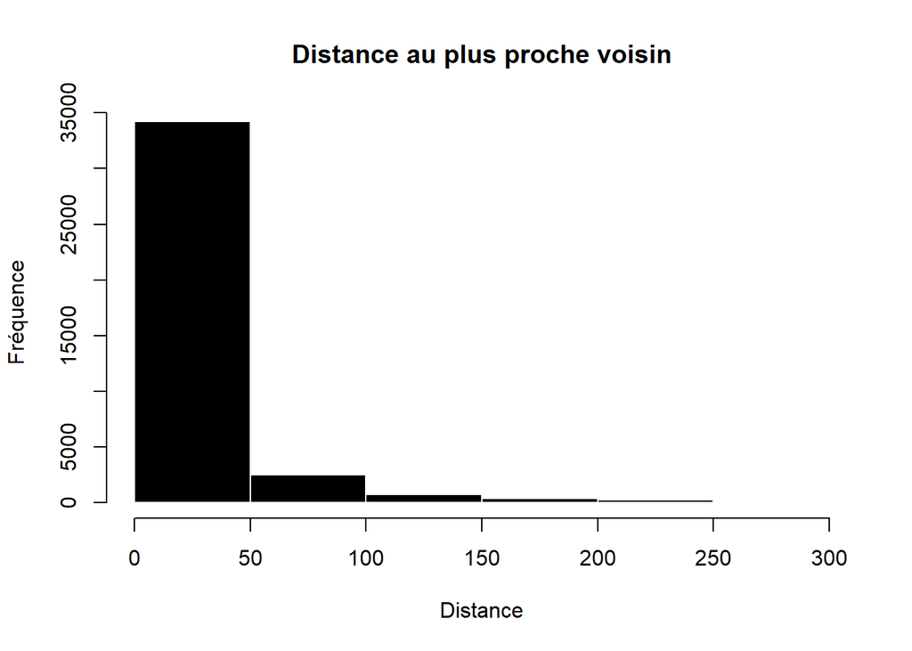

```r
hist(unlist(distPPV), nclass = 200,
     main = "Distance au plus proche voisin",
     col = "black", border = "white", xlab = "Distance", ylab = "Fréquence", xlim = c(0,300))
```

```r
#calcul du test de Moran
moran.test(MutationsPaysBasque$prixm2, listw = nb2listw(PPV))
```

```
##
##  Moran I test under randomisation
##
## data:  MutationsPaysBasque$prixm2
## weights: nb2listw(PPV)
##
## Moran I statistic standard deviate = 87.484, p-value < 2.2e-16
## alternative hypothesis: greater
## sample estimates:
## Moran I statistic       Expectation          Variance
##      5.212308e-01     -2.568911e-05      3.550171e-05
```

### Carte lissée des prix de l’immobilier au m² calculés directement à partir des mutations immobilières sur l’ensemble du Pays Basque

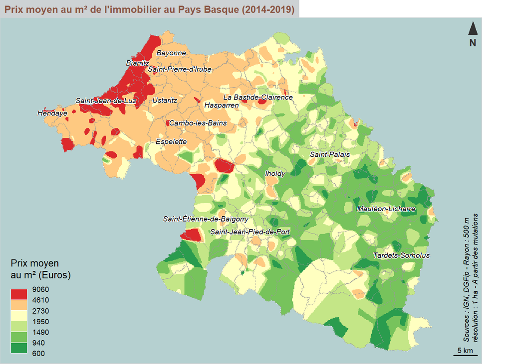

```r
# pour définir comme emprise pour le lissage, l'étendue du Pays Basque avec une zone tampon de 0,5 km autour afin d'englober les mutations limitrophes et réduire l'effet de bord
EmprisePB.ZT <- as.owin(st_geometry(st_buffer(EPCI, 500)))

# Extraction des coordonnées spatiales
coordinates <- st_coordinates(MutationsPaysBasque)

# pour créer un objet ppp (format spatstat) et y intégrer dedans l'emprise et les valeurs à lisser (prix moyen au m²)
# NB : on considère dans un premier temps les mutations sur l'ensemble du Pays Basque, et on ne retient que celles qui sont incluses dans l'emprise créée à l'étape précédente
MutationsPaysBasque.ppp <- ppp(x = coordinates[, 1], y = coordinates[, 2], window = EmprisePB.ZT, marks = MutationsPaysBasque$prixm2)

# pour calculer la surface lissée (rayon lissage : 0,5 km et résolution spatiale de l'image : 1 ha) --> calcul long
cartelissee <- Smooth(MutationsPaysBasque.ppp, sigma = 500, weights = MutationsPaysBasque.ppp$marks, eps = 100)

# Conversion de la surface lissée au format raster
cartelissee.raster <- terra::rast(cartelissee)
crs(cartelissee.raster) <- st_crs(COM_PB)$srid

# découpage de la surface lissée sur l'emprise Pays Basque
cartelissee.raster <- mask(cartelissee.raster, COM_PB)

# Paramétrage des marges de la fenêtre pour maximiser l'emprise de la carte
par(mar = c(0, 0, 1.2, 2))

# pour afficher la surface lissée et définir l'habillage de la carte
# Calcul des seuils
bks <- unique(getBreaks(values(cartelissee.raster), method = "q6"))

# Création d'une palette de couleurs (double gradation harmonique)
cols <- c("#2a9c4e", "#77c35c", "#c4e687", "#ffffc0", "#fec981", "#dc292c")

# Affichage des communes de Pays Basque et alentours en arrière-plan et centrage de la carte sur Pays Basque
plot(st_geometry(EPCI), lwd = 0.1, col = "grey95", border = "white", bg = "#B5D0D0", xlim = c(st_bbox(COM_PB)[1], st_bbox(COM_PB)[3]), ylim = c(st_bbox(COM_PB)[2], st_bbox(COM_PB)[4]))

# Affichage de la carte lissée et du contour des communes
plot(cartelissee.raster, breaks = bks, col = cols, add = T, legend = F)
plot(COM_PB$geom, border = "grey60", lwd = 0.05, lty = 3, add = T)

legendChoro(
  pos = "bottomleft",
  title.txt = "Prix moyen \nau m² (Euros)",
  breaks = bks,
  nodata = FALSE,
  values.rnd = -1,
  border = "white",
  col = cols
)

layoutLayer(title = "Prix moyen au m² de l'immobilier au Pays Basque (2014-2019)",
            author = "         Sources : IGN, DGFip - Rayon : 500 m\n         résolution : 1 ha - A partir des mutations",
            scale = 5, frame = TRUE, col = "#cdd2d4", coltitle = "#8A5543",
            north = TRUE, tabtitle = TRUE, horiz = FALSE)

# Ajouter les étiquettes des communes sélectionnées plus haut
labelLayer(Selection_communes_PaysBasque, txt = "NOM", halo = TRUE, bg = "white", r = 0.05, cex = 0.6, pos = 3, font = 3, offset = 0)
```

## Elaboration d’une typologie à partir d’indicateurs immobiliers et cartographie des sous-marchés associés (échelle de l’EPCI)

### Transfert d’attributs des communes vers les mutations (jointure spatiale)

```r
MutationsCom <- MutationsPaysBasque %>% st_join(COM_PB)
MutationsCom <- as.data.frame(MutationsCom)
```

### Création d’un tableau avec les variables par communes à soumettre à la CAH

```r
COMDVFClassif1 <- MutationsCom %>% group_by(codecommune) %>%
  summarise(Nbtransactions = n(),
            Prixmoyen = round(mean(prix)),
            Prixm2moyen = round(mean(prixm2)),
            Surfacemoyenne = round(mean(surface)),
            PropMaison = length(type[type == "Maison"]) / Nbtransactions * 100,
            PropAppart = length(type[type == "Appartement"]) / Nbtransactions * 100)

COMDVFClassif <- data.frame(COMDVFClassif1[, c("Nbtransactions", "Prixmoyen", "Prixm2moyen", "Surfacemoyenne", "PropMaison", "PropAppart")])
```

### Centrage et réduction des variables

```r
COMDVFClassifScale <- scale(COMDVFClassif)
```

### Mise en oeuvre de la CAH

```r
CAHCOM <- agnes(COMDVFClassifScale,
                     metric = "euclidean",
                     method = "ward")
```

### Graphiques des gains d’inertie inter-classe

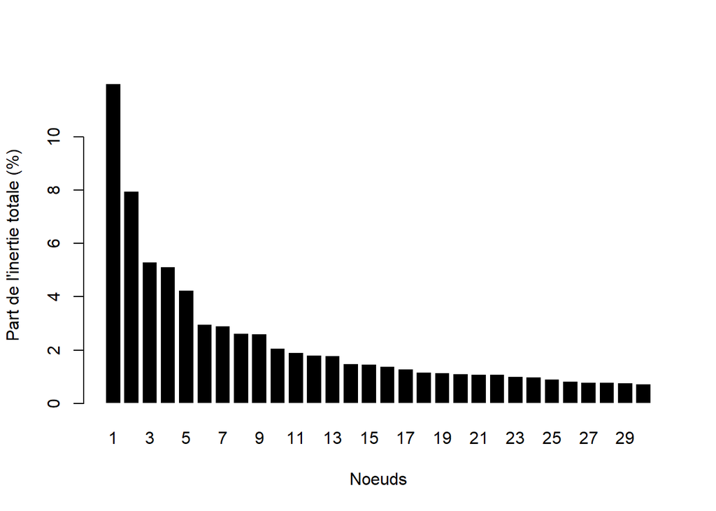

```r
sortedHeight<- sort(CAHCOM$height, decreasing = TRUE)
relHeight<-sortedHeight/ sum(sortedHeight) * 100
cumHeight<- cumsum(relHeight)

barplot(relHeight[1:30], names.arg = seq(1, 30, 1), col = "black", border = "white", xlab = "Noeuds", ylab = "Part de l'inertie totale (%)")
```

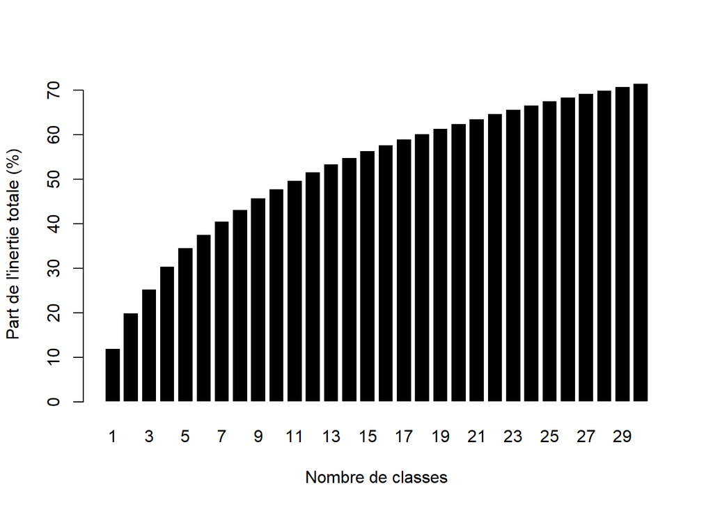

```r
barplot(cumHeight[1:30], names.arg = seq(1, 30, 1), col = "black", border = "white", xlab = "Nombre de classes", ylab = "Part de l'inertie totale (%)")
```

### Arbre de classification hiérarchique

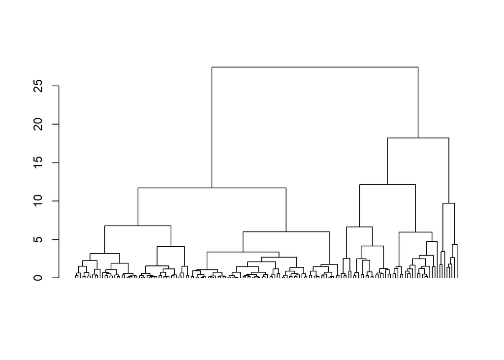

```r
dendroCSP <- as.dendrogram(CAHCOM)
plot(dendroCSP, leaflab = "none")
```

### Partition (en n classes)

```r
clusCOM <- cutree(CAHCOM, k = 5)
COMCluster <- COMDVFClassif1
COMCluster$CLUSIMMO <- factor(clusCOM,
                                   levels = 1:5,
                                   labels = paste("Classe", 1:5))
```

### Création d’un tableau avec les caractéristiques des groupes

```r
RecapCAHCOM <- COMCluster %>% group_by(CLUSIMMO) %>% summarise(NB= n(), NbTransac = round(mean(Nbtransactions)), Prixmoyen = round(mean(Prixmoyen)), Prixm2 = round(mean(Prixm2moyen)), Surface = round(mean(Surfacemoyenne)), PropMaison = mean(PropMaison), PropAppart = mean(PropAppart))

print(RecapCAHCOM)
```

```
## # A tibble: 5 × 8
##   CLUSIMMO    NB NbTransac Prixmoyen Prixm2 Surface PropMaison PropAppart
##   <fct>    <int>     <dbl>     <dbl>  <dbl>   <dbl>      <dbl>      <dbl>
## 1 Classe 1    47        21    219522   1764     130       93.9       6.14
## 2 Classe 2    21       162    347641   3066     117       74.7      25.3
## 3 Classe 3    61        14    135814   1350     104       97.5       2.52
## 4 Classe 4     8      3472    333658   4625      71       20.8      79.2
## 5 Classe 5    19       312    199418   2256      92       48.3      51.7
```

### Graphique des écarts à la moyenne

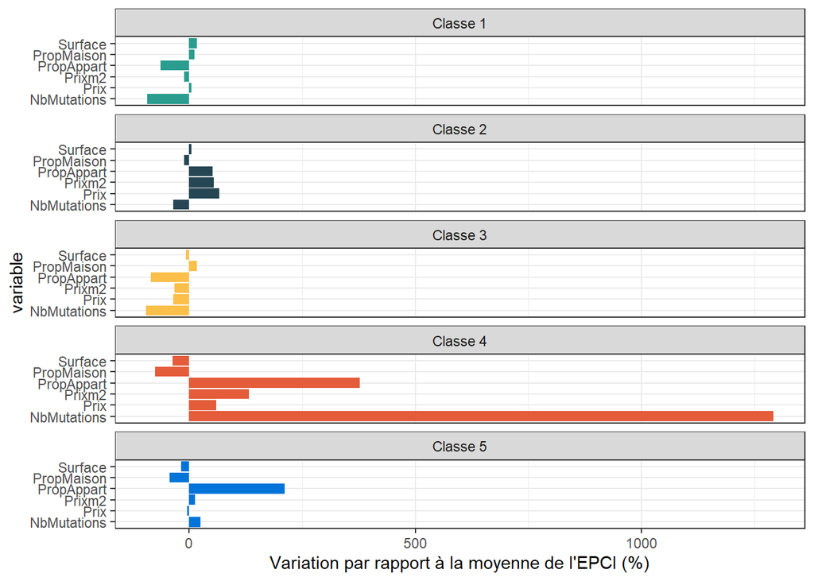

```r
SyntheseCAHCOM <- RecapCAHCOM %>% mutate(
  nbtransacmoy = mean(COMDVFClassif$Nbtransactions),
  surfacemoy = mean(COMDVFClassif$Surfacemoyenne),
  prixmoy = mean(COMDVFClassif$Prixmoyen),
  prixm2moyen = mean(COMDVFClassif$Prixm2moyen),
  propmaisonmoyen = mean(COMDVFClassif$PropMaison),
  propappartmoyen = mean(COMDVFClassif$PropAppart),
  NbMutations = (NbTransac - nbtransacmoy) / nbtransacmoy * 100,
  Prix = (Prixmoyen - prixmoy) / prixmoy * 100,
  Prixm2 = (Prixm2 - prixm2moyen) / prixm2moyen * 100,
  Surface = (Surface - surfacemoy) / surfacemoy * 100,
  PropMaison = (PropMaison - propmaisonmoyen) / propmaisonmoyen * 100,
  PropAppart = (PropAppart - propappartmoyen) / propappartmoyen * 100
)

# pour créer un nouveau tableau avec une sélection de colonnes à faire apparaître sur le graphique
SyntheseCAHCOM <- data.frame(SyntheseCAHCOM[, c("CLUSIMMO", "NbMutations", "Surface", "Prix", "Prixm2", "PropMaison", "PropAppart")])

gather <- SyntheseCAHCOM %>% gather(key = variable, value = "value", NbMutations:PropAppart)

ggplot(gather, aes(x = variable, y = value, fill = CLUSIMMO)) +
  geom_bar(stat = "identity") +
  coord_flip() +
  scale_fill_manual(values = c("#2A9D8F","#264653","#fcbf49","#e45c3a","#0074D9")) +
  ylab("Variation par rapport à la moyenne de l'EPCI (%)") +
  theme_bw() +
  theme(legend.position = "none") +
  facet_wrap(~CLUSIMMO, ncol = 1)
```

### Carte de la typologie montrant les sous-marchés immobiliers des EPCIS

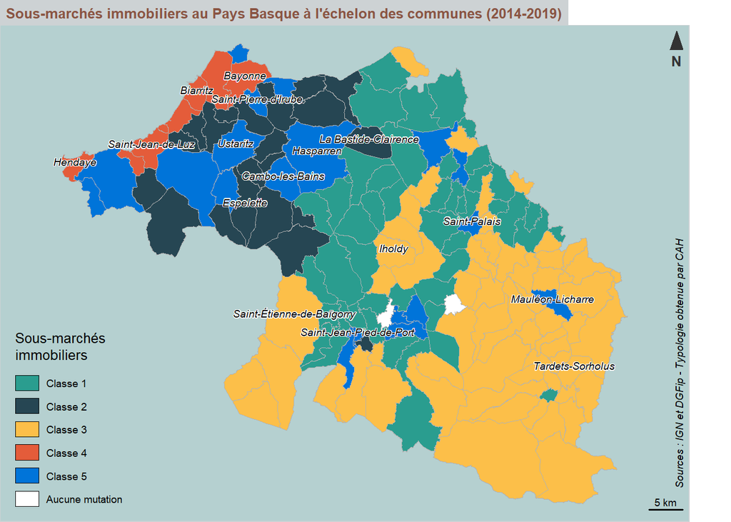

```r
# pour joindre le résultat de la typologie dans la couche des IRIS
COMCluster <- COMCluster %>% mutate(INSEE_COM= as.character(codecommune))
COMDVFCAH <- left_join(COM_PB, COMCluster, by = "INSEE_COM")

# Paramétrage des marges de la fenêtre pour maximiser l'emprise de la carte
par(mar = c(0, 0, 1.2, 2))

# pour afficher la surface lissée et définir l'habillage de la carte
# Calcul des seuils
bks <- unique(getBreaks(values(cartelissee.raster), method = "q6"))

# Création d'une palette de couleurs (double gradation harmonique)
cols <- c("#2a9c4e", "#77c35c", "#c4e687", "#ffffc0", "#fec981", "#dc292c")

# Affichage des communes du Pays Basque et alentours en arrière-plan et centrage de la carte sur l'EPCI
plot(st_geometry(EPCI), lwd = 0.1, col = "grey95", border = "white", bg = "#B5D0D0", xlim = c(st_bbox(COM_PB)[1], st_bbox(COM_PB)[3]), ylim = c(st_bbox(COM_PB)[2], st_bbox(COM_PB)[4]))

# Affichage de la typologie et du contour des communes
typoLayer(
  x = COMDVFCAH,
  var="CLUSIMMO",
  col = c("#2A9D8F","#264653","#fcbf49","#e45c3a","#0074D9"),
  lwd = 0.05,
  border = "grey70",
  legend.values.order = c("Classe 1",
                          "Classe 2",
                          "Classe 3",
                          "Classe 4",
                          "Classe 5"),
  legend.pos = "bottomleft",
  legend.title.txt = "Sous-marchés \nimmobiliers",
  legend.nodata = "Aucune mutation",
  add = TRUE)

layoutLayer(title = "Sous-marchés immobiliers au Pays Basque à l'échelon des communes (2014-2019)",
            author = "          Sources : IGN et DGFip - Typologie obtenue par CAH",
            scale = 5, frame = TRUE, col = "#cdd2d4", coltitle = "#8A5543",
            north = TRUE, tabtitle = TRUE, horiz = FALSE)

# Ajouter les étiquettes des communes sélectionnées plus haut
labelLayer(Selection_communes_PaysBasque, txt = "NOM", halo = TRUE, bg = "white", r = 0.05, cex = 0.6, pos = 3, font = 3, offset = 0)
```

### Export des communes contenant la typologie issue de la CAH au format geopackage (pour une utilisation dans un SIG par exemple)

```r
st_write(COMDVFCAH, "COMDVFCAH.gpkg", append = FALSE)
```

```
## Deleting layer `COMDVFCAH' using driver `GPKG'
## Writing layer `COMDVFCAH' to data source `COMDVFCAH.gpkg' using driver `GPKG'
## Writing 158 features with 24 fields and geometry type Multi Polygon.
```

### Préparation du jeu de données

```r
# pour ne garder que la commmune de Biarritz
CommuneBiarritz <- COM_PB %>% filter(NOM == "Biarritz")

# pour ne garder que les mutations correspondant à des appartements au Pays Basque (dans un premier temps)
MutationsApptPB <- MutationsPaysBasque %>% filter(type == "Appartement")

# pour créer une liste d'années, dans l'ordre
MutationsApptPB <- MutationsApptPB[order(MutationsApptPB$annee, decreasing = FALSE), ]
ListAnnees <- unique(MutationsApptPB$annee)

# pour définir comme emprise pour le lissage, l'étendue de Biarritz avec une zone tampon de 0,5 km autour afin d'englober les mutations limitrophes et réduire l'effet de bord
EmpriseBiarritz <- as.owin(st_buffer(st_geometry(CommuneBiarritz), 500))

# Création d'une palette de couleurs
cols <- c("#fee1d3", "#fcbea5", "#fc9777", "#fb7050", "#f14432", "#d42020", "#ad1016", "#67000d", "#480000", "#300000")
```

### Série de cartes lissées montrant l’évolution des prix au m² des appartements calculés directement à partir des mutations à Biarritz

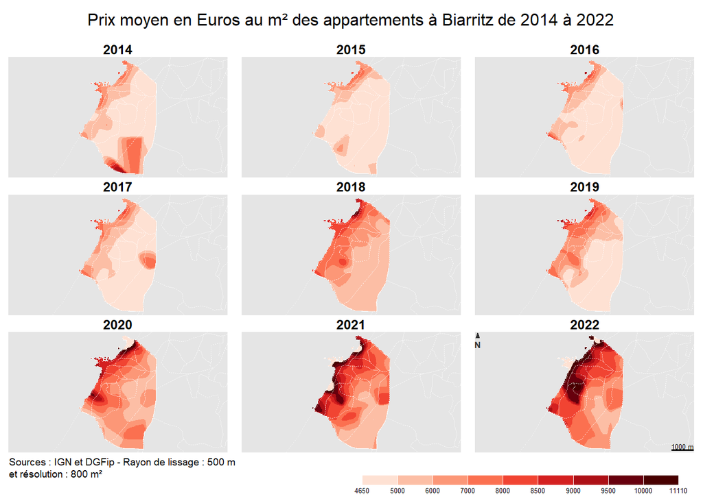

```r
# Paramétrage des marges pour insérer le titre général et les titres de chaque carte
par(oma = c(3.5,0,3,0)+0.1, mar = c(0, 0.5, 1.2, 0.5))

# pour découper la fenêtre en 2 lignes et 3 colonnes (6 années)
par(mfrow = c(3,3))

# boucle pour produire et cartographier une surface lissée par année
for (i in ListAnnees){

  # Recuperation des jeux de données par année
  fichier <- MutationsApptPB[which(MutationsApptPB$annee == i),]

  # pour récupérer les coordonnées des mutations
  pts <- st_coordinates(st_geometry(fichier))

  # pour creer un objet ppp (format spatstat) et y integrer dedans l'emprise et les valeurs a lisser (prix au m²)
  fichier.ppp <- ppp(pts[,1], pts[,2], window = EmpriseBiarritz, marks = fichier$prixm2)

  # pour calculer la surface lissee (rayon lissage : 500 m et resolution spatiale de l'image : 1000m²)
  cartelissee <- Smooth(fichier.ppp, sigma = 200, weights = fichier.ppp$marks, eps = sqrt(800))

  # Conversion de la surface lissée au format raster
  cartelissee.raster <- rast(cartelissee)
  crs(cartelissee.raster) <- st_crs(CommuneBiarritz)$srid # pour spécifier un SCR à l'objet raster
  cartelissee.raster <- mask(cartelissee.raster, CommuneBiarritz) # découpage sur emprise Biarritz

  # Définition manuelle des seuils
  bks <- c(min(values(cartelissee.raster), na.rm = TRUE), 5000, 6000, 7000, 8000, 8500, 9000, 9500, 10000, max(values(cartelissee.raster), na.rm = TRUE))

  # reclassification de la surface lissée
  cartelissee.reclass <- classify(cartelissee.raster, rcl = bks)

  # vectorisation de la surface reclassée
  cartelissee.vecteur <- st_as_sf(as.polygons(cartelissee.reclass))

  # trier les valeurs
  cartelissee.vecteur <- cartelissee.vecteur[order(cartelissee.vecteur$lyr.1, decreasing = FALSE), ]

  # Tracer la carte
  plot(st_geometry(CommuneBiarritz), border = "white", bg = "grey90")

  typoLayer(x = cartelissee.vecteur, var = "lyr.1", col = cols, lwd = 0.1,
    border = NA, legend.pos = "n", add = TRUE)

  plot(st_geometry(IRISPB), border = adjustcolor("white", alpha.f = 0.5), lty = 3, lwd = 0.01, add = TRUE)

  title(main = paste("", i, sep = ""))

}

barscale(lwd = 1.5, cex = 0.6, pos = "bottomright", style = "pretty", unit = "m")
cartography::north(pos = "topleft")

# Pour afficher le titre principal et la source
mtext("Prix moyen en Euros au m² des appartements à Biarritz de 2014 à 2022", cex = 1, side = 3, line = 1, adj = 0.5, outer = TRUE)
mtext("   Sources : IGN et DGFip - Rayon de lissage : 500 m\n   et résolution : 800 m²", side = 1, line = 1, adj = 0, cex = 0.6, outer = TRUE)

# Affichage de la légende (dans une nouvelle fenêtre graphique)
par(fig = c(0, 1, 0, 1), oma = c(0, 0, 0, 0), mar = c(0, 0, 0, 0), new = TRUE)
plot.new()

legendChoro(
  pos = "bottomright",
  title.txt = "",
  breaks = bks,
  nodata = FALSE,
  values.rnd = -1,
  col = cols,
  border = "white",
  horiz = TRUE
)
```

### Préparation du jeu de données

```r
# pour ne garder que la commmune de Biarritz
CommuneBiarritz <- COM_PB %>% filter(NOM == "Biarritz")

# pour ne garder que les mutations correspondant à des maisons au Pays Basque (dans un premier temps)
MutationsMaisPB <- MutationsPaysBasque %>% filter(type == "Maison")

# pour créer une liste d'années, dans l'ordre
MutationsMaisPB <- MutationsMaisPB[order(MutationsMaisPB$annee, decreasing = FALSE), ]
ListAnnees <- unique(MutationsMaisPB$annee)

# pour définir comme emprise pour le lissage, l'étendue de Biarritz avec une zone tampon de 0,5 km autour afin d'englober les mutations limitrophes et réduire l'effet de bord
EmpriseBiarritz <- as.owin(st_buffer(st_geometry(CommuneBiarritz), 500))

# Création d'une palette de couleurs
cols <- c("#fee1d3", "#fcbea5", "#fc9777", "#fb7050", "#f14432", "#d42020", "#ad1016", "#67000d", "#480000", "#300000")
```

### Série de cartes lissées montrant l’évolution des prix au m² des maisons calculés directement à partir des mutations à Biarritz

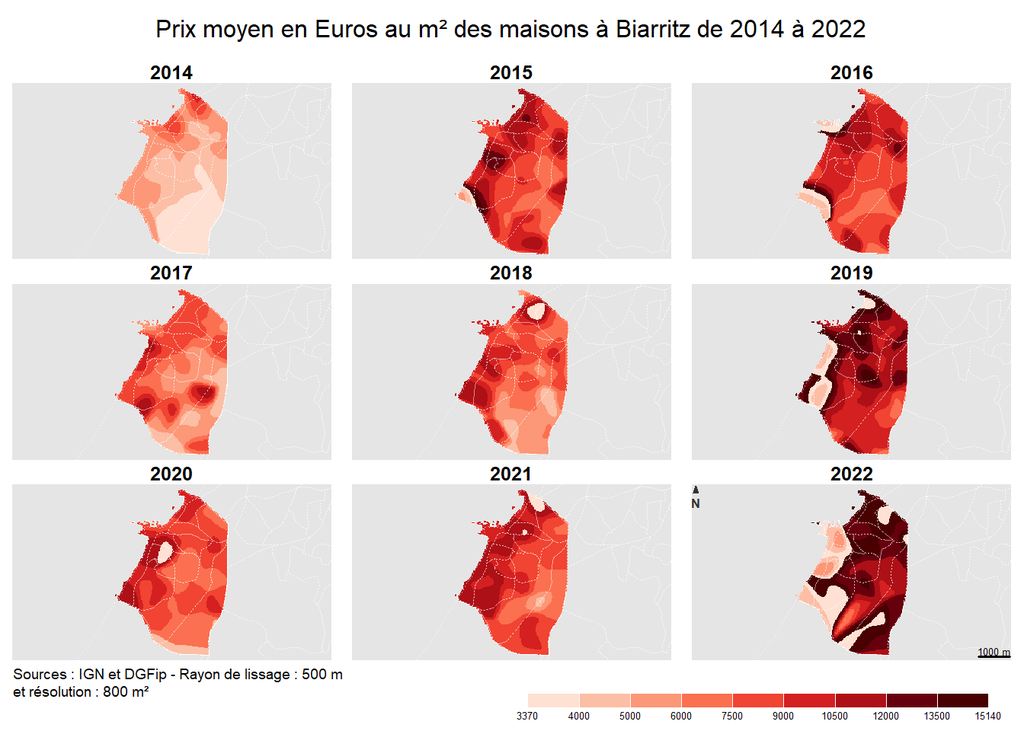

```r
# Paramétrage des marges pour insérer le titre général et les titres de chaque carte
plot.new()
par(oma = c(3.5,0,3,0)+0.1, mar = c(0, 0.5, 1.2, 0.5))

# pour découper la fenêtre en 2 lignes et 3 colonnes (6 années)
par(mfrow = c(3,3))

# boucle pour produire et cartographier une surface lissée par année
for (i in ListAnnees){

  # Recuperation des jeux de données par année
  fichier <- MutationsMaisPB[which(MutationsMaisPB$annee == i),]

  # pour récupérer les coordonnées des mutations
  pts <- st_coordinates(st_geometry(fichier))

  # pour creer un objet ppp (format spatstat) et y integrer dedans l'emprise et les valeurs a lisser (prix au m²)
  fichier.ppp <- ppp(pts[,1], pts[,2], window = EmpriseBiarritz, marks = fichier$prixm2)

  # pour calculer la surface lissee (rayon lissage : 500 m et resolution spatiale de l'image : 1000m²)
  cartelissee <- Smooth(fichier.ppp, sigma = 200, weights = fichier.ppp$marks, eps = sqrt(800))

  # Conversion de la surface lissée au format raster
  cartelissee.raster <- rast(cartelissee)
  crs(cartelissee.raster) <- st_crs(CommuneBiarritz)$srid # pour spécifier un SCR à l'objet raster
  cartelissee.raster <- mask(cartelissee.raster, CommuneBiarritz) # découpage sur emprise Biarritz

  # Définition manuelle des seuils
  bks <- c(min(values(cartelissee.raster), na.rm = TRUE), 4000, 5000, 6000, 7500, 9000, 10500, 12000, 13500, max(values(cartelissee.raster), na.rm = TRUE))

  # reclassification de la surface lissée
  cartelissee.reclass <- classify(cartelissee.raster, rcl = bks)

  # vectorisation de la surface reclassée
  cartelissee.vecteur <- st_as_sf(as.polygons(cartelissee.reclass))

  # trier les valeurs
  cartelissee.vecteur <- cartelissee.vecteur[order(cartelissee.vecteur$lyr.1, decreasing = FALSE), ]

  # Tracer la carte
  plot(st_geometry(CommuneBiarritz), border = "white", bg = "grey90")

  typoLayer(x = cartelissee.vecteur, var = "lyr.1", col = cols, lwd = 0.1,
    border = NA, legend.pos = "n", add = TRUE)

  plot(st_geometry(IRISPB), border = adjustcolor("white", alpha.f = 0.5), lty = 3, lwd = 0.01, add = TRUE)

  title(main = paste("", i, sep = ""))

}

barscale(lwd = 1.5, cex = 0.6, pos = "bottomright", style = "pretty", unit = "m")
cartography::north(pos = "topleft")

# Pour afficher le titre principal et la source
mtext("Prix moyen en Euros au m² des maisons à Biarritz de 2014 à 2022", cex = 1, side = 3, line = 1, adj = 0.5, outer = TRUE)
mtext("   Sources : IGN et DGFip - Rayon de lissage : 500 m\n   et résolution : 800 m²", side = 1, line = 1, adj = 0, cex = 0.6, outer = TRUE)

# Affichage de la légende (dans une nouvelle fenêtre graphique)
par(fig = c(0, 1, 0, 1), oma = c(0, 0, 0, 0), mar = c(0, 0, 0, 0), new = TRUE)
plot.new()

legendChoro(
  pos = "bottomright",
  title.txt = "",
  breaks = bks,
  nodata = FALSE,
  values.rnd = -1,
  col = cols,
  border = "white",
  horiz = TRUE
)
```

## Exploration d’un autre mode de représentation : les cartes linemap

### Appartements

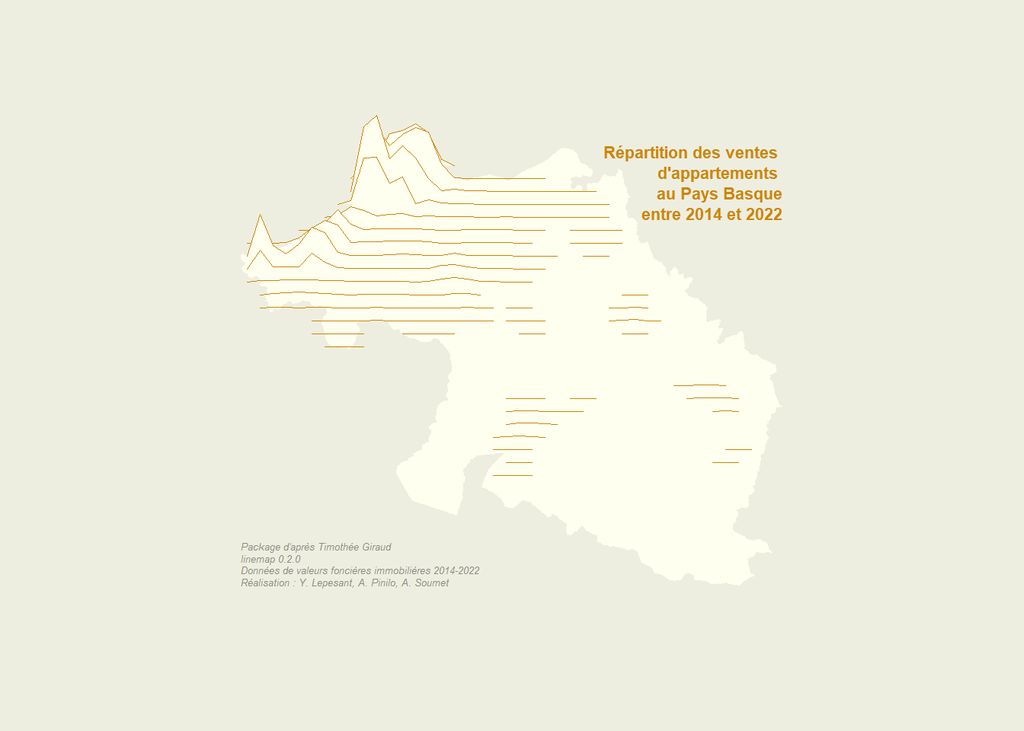

```r
# création du carroyage
grid <- getgrid(x = COM_PB, cellsize = 2000, var = "NbAppart")

# préparation de la fenêtre graphique
opar <- par(mar=c(0,0,0,0), bg = "ivory2", pin = c(4,4))

# affichage de la carte
plot(st_geometry(COM_PB), col="ivory1", border = NA)

linemap(
  x = grid,
  var = "NbAppart",
  k = 8,
  threshold = 1,
  col = "ivory1",
  border = "orange3",
  lwd = 0.6,
  add = TRUE
)

bb <- st_bbox(COM_PB)


text(x = bb[3], y = bb[4], adj = c(1,1),
     labels = "Répartition des ventes \nd'appartements \nau Pays Basque\nentre 2014 et 2022",
     col = "orange3", font = 2,  cex = 0.7)

# add sources
mapsources <-"Package d'après Timothée Giraud\nlinemap 0.2.0\nDonnées de valeurs foncières immobilières 2014-2022\nRéalisation : Y. Lepesant, A. Pinilo, A. Soumet"
text(x = bb[1], y = bb[2],labels = mapsources,
     col = "ivory4", font = 3, adj = c(0,0), cex = 0.4 )
```

```r
par(opar)
```

### Maisons

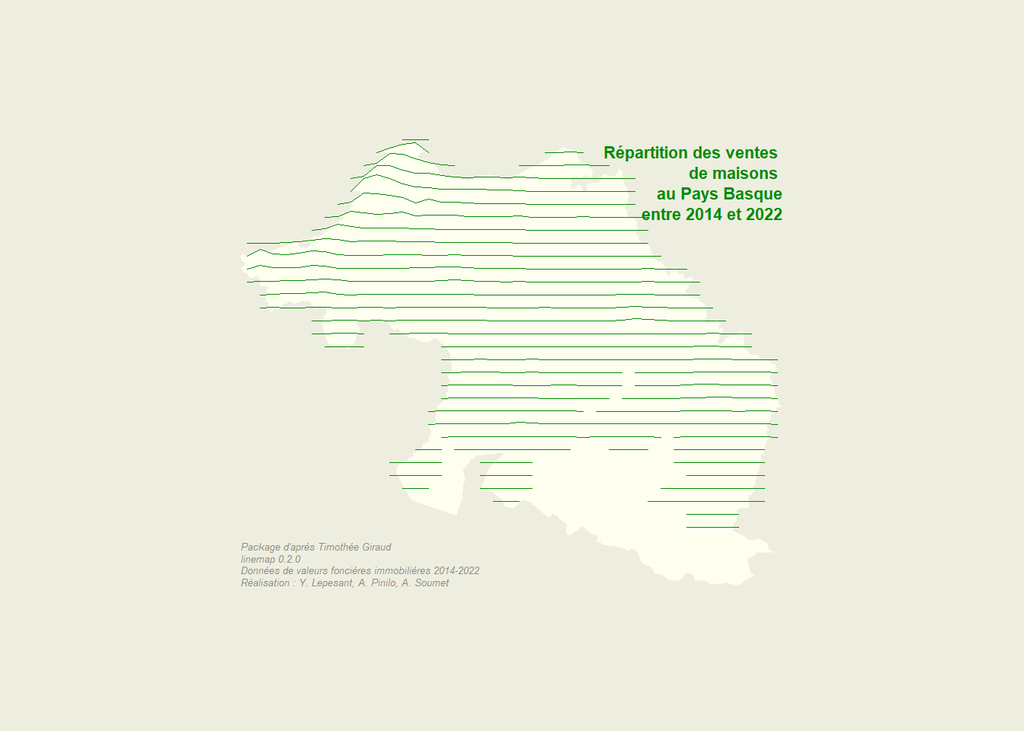

```r
# création du carroyage
grid <- getgrid(x = COM_PB, cellsize = 2000, var = "NbMaisons")

# préparation de la fenêtre graphique
opar <- par(mar=c(0,0,0,0), bg = "ivory2", pin = c(4,4))

# affichage de la carte
plot(st_geometry(COM_PB), col="ivory1", border = NA)

linemap(
  x = grid,
  var = "NbMaisons",
  k = 8,
  threshold = 1,
  col = "ivory1",
  border = "green4",
  lwd = 0.6,
  add = TRUE
)

bb <- st_bbox(COM_PB)


text(x = bb[3], y = bb[4], adj = c(1,1),
     labels = "Répartition des ventes \nde maisons \nau Pays Basque\nentre 2014 et 2022",
     col = "green4", font = 2,  cex = 0.7)

# add sources
mapsources <-"Package d'après Timothée Giraud\nlinemap 0.2.0\nDonnées de valeurs foncières immobilières 2014-2022\nRéalisation : Y. Lepesant, A. Pinilo, A. Soumet"
text(x = bb[1], y = bb[2],labels = mapsources,
     col = "ivory4", font = 3, adj = c(0,0), cex = 0.4 )
```

```r
par(opar)
```

### Prix m2

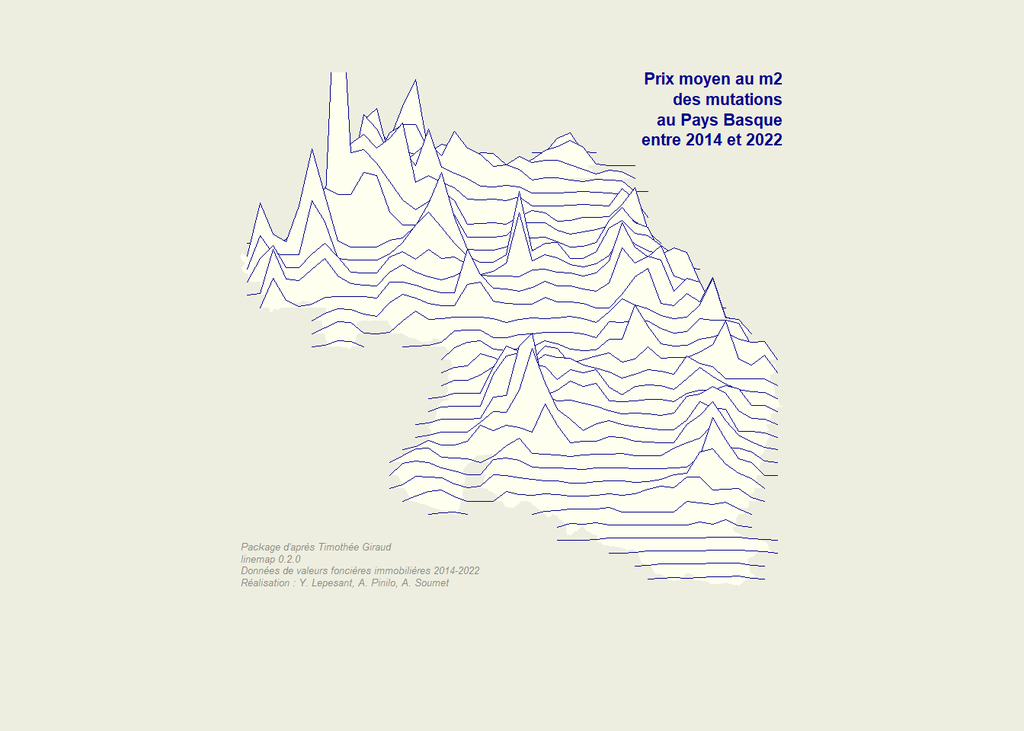

```r
# création du carroyage
grid <- getgrid(x = COM_DVF, cellsize = 2000, var = "Prixm2")

# préparation de la fenêtre graphique
opar <- par(mar=c(0,0,0,0), bg = "ivory2", pin = c(4,4))

# affichage de la carte
plot(st_geometry(COM_PB), col="ivory1", border = NA)

linemap(
  x = grid,
  var = "Prixm2",
  k = 8,
  threshold = 1,
  col = "ivory1",
  border = "blue4",
  lwd = 0.6,
  add = TRUE
)

bb <- st_bbox(COM_PB)

text(x = bb[3], y = bb[4], adj = c(1,0),
     labels = "Prix moyen au m2\ndes mutations\nau Pays Basque\nentre 2014 et 2022",
     col = "blue4", font = 2,  cex = 0.7)

# add sources
mapsources <-"Package d'après Timothée Giraud\nlinemap 0.2.0\nDonnées de valeurs foncières immobilières 2014-2022\nRéalisation : Y. Lepesant, A. Pinilo, A. Soumet"
text(x = bb[1], y = bb[2],labels = mapsources,
     col = "ivory4", font = 3, adj = c(0,0), cex = 0.4)
```

```r
par(opar)
```